# Lab 10: Metropolis–Hastings

STAT 536 — Statistical Computing (solutions)

Author

Soumojit Das

Published

Fall 2026

# Setup

Figure labels are typeset by LaTeX. `tikz_png()` draws a ggplot through `tikzDevice`, compiles it with `pdflatex`, and returns a PNG. It needs a LaTeX installation (TinyTeX is enough) and installs `tikzDevice`, `pdftools`, and `png` on first use. Both problems use `effectiveSize()` from the `coda` package, which the setup chunk installs if it is missing.

```r
library(ggplot2)
library(patchwork)
if (!requireNamespace("coda", quietly = TRUE)) install.packages("coda")
set.seed(536)
theme_set(theme_bw(base_size = 14))

pal <- c(red = "#D62828", blue = "#2E86AB", green = "#06A77D",
         orange = "#F77F00", dark = "#023047", grey = "#6a6a6a")

find_pdflatex <- function() {
  cand <- c(Sys.which("pdflatex"),
            path.expand("~/Library/TinyTeX/bin/universal-darwin/pdflatex"),
            file.path(Sys.getenv("APPDATA"), "TinyTeX/bin/windows/pdflatex.exe"),
            path.expand("~/.TinyTeX/bin/x86_64-linux/pdflatex"))
  cand <- cand[nzchar(cand) & file.exists(cand)]
  if (!length(cand)) stop("pdflatex not found; install TinyTeX with tinytex::install_tinytex()")
  cand[[1]]
}

tikz_png <- function(p, png_file, width = 9, height = 5, dpi = 150) {
  for (pkg in c("tikzDevice", "pdftools", "png"))
    if (!requireNamespace(pkg, quietly = TRUE)) install.packages(pkg)
  options(tikzLatex = find_pdflatex(),
          tikzDocumentDeclaration = r"(\documentclass[10pt]{article})",
          tikzLatexPackages = c(r"(\usepackage{tikz})",
                                r"(\usepackage[active,tightpage,psfixbb]{preview})",
                                r"(\PreviewEnvironment{pgfpicture})",
                                r"(\setlength\PreviewBorder{0pt})",
                                r"(\usepackage[T1]{fontenc})", r"(\usepackage{lmodern})",
                                r"(\usepackage{amsmath})"))
  work <- file.path(tempdir(), "tikz_png"); dir.create(work, showWarnings = FALSE)
  tex <- file.path(work, "fig.tex"); pdf <- file.path(work, "fig.pdf")
  tikzDevice::tikz(tex, width = width, height = height, standAlone = TRUE)
  print(p); dev.off()
  ok <- system2(getOption("tikzLatex"),
                c("-interaction=batchmode", "-halt-on-error",
                  paste0("-output-directory=", shQuote(work)), shQuote(tex)),
                stdout = FALSE, stderr = FALSE)
  if (ok != 0 || !file.exists(pdf)) stop("pdflatex failed; see ", file.path(work, "fig.log"))
  dir.create(dirname(png_file), recursive = TRUE, showWarnings = FALSE)
  png::writePNG(pdftools::pdf_render_page(pdf, page = 1, dpi = dpi), png_file)
  png_file
}

# tick labels in math mode, so minus signs and decimals are set by LaTeX
tex_num <- function(v) ifelse(is.na(v), NA,
  paste0("$", format(v, scientific = FALSE, drop0trailing = TRUE, trim = TRUE), "$"))
tex_theme <- theme(text = element_text(size = 17), plot.title = element_text(hjust = 0.5),
                   legend.position = "top", legend.key.width = unit(1.2, "cm"))
# whole-number ticks for a time axis
int_breaks <- function(lim) unique(round(pretty(lim)))
```

# Notation

The lab uses these symbols.

| Symbol | Meaning |
| --- | --- |
| $X_t$ | the state at time $t = 0, 1, 2, \ldots$ |
| $N$ | the chain length |
| $\pi$ | the target density |
| $q(y \mid x)$, $Y$ | the proposal density from $x$ to $y$, and the proposed value |
| $\alpha(x, y)$ | the acceptance probability |
| $r_{\text{rej}}(x)$ | the rejection probability at $x$, $1 - \int q(y \mid x)\,\alpha(x, y)\,dy$ |
| $Z$, $s$ | the normal step of a log-scale proposal, and its standard deviation |
| $u$, $v$ | $\log x$ and $\log y$ |
| $\phi(y; m, s^2)$ | the $\Normal(m, s^2)$ density at $y$ |
| $\lambda$, $\mathbf{x}$ | the Poisson rate and the observed counts of the Gamma posterior |
| $w(x)$, $M$ | the importance weight $\pi(x)/q(x)$, and a bound on it |
| $\sigma$ | the standard deviation of an independence proposal, `q_sd` in the code |
| ESS | the effective sample size, from `coda::effectiveSize()` |

Every problem ends with a **Report** list. Interpretation references the specific values you computed, not generic textbook claims.

# Problem 1: The Hastings Correction for a Log-Scale Proposal

A positive parameter can be proposed on the log scale, so that every proposal is positive. This problem uses the proposal and the acceptance probability below.

**NoteLog-scale proposal**

Propose $Y = x\,e^{Z}$, with $Z \sim \Normal(0, s^2)$. Then $\log Y \sim \Normal(\log x, s^2)$, and

$$q(y \mid x) = \frac{\phi(\log y; \log x, s^2)}{y}, \qquad \frac{q(x \mid y)}{q(y \mid x)} = \frac{y}{x}.$$

The Metropolis–Hastings acceptance probability is

$$\alpha(x, y) = \min\left(1, \frac{\pi(y)}{\pi(x)} \cdot \frac{y}{x}\right).$$

The factor $y/x$ is the Hastings correction.

We run the chain on $u = \log x$. There the proposal is the random walk $v = u + Z$, with $v = \log y$, and the log of the ratio inside $\alpha$ is

$$\log\pi(e^{v}) - \log\pi(e^{u}) + (v - u).$$

The last term, $v - u = \log(y/x)$, is the log of the correction.

1. Complete `mh_log_scale(N, s, x0, log_pi, correct)` below. It runs the chain on $u = \log x$ and returns $u_0, u_1, \ldots, u_N$ and the acceptance rate. With `correct = TRUE` the log ratio includes $v - u$. With `correct = FALSE` it leaves it out. Run it on the target $\Exp(1)$, with `log_pi_exp(x) = -x` as `log_pi`, $N = 10^5$, $s = 1$, $x_0 = 1$, and `correct = FALSE`. Compute the acceptance rate, the share of draws below 0.2, and the mean and the median of $X_1, \ldots, X_N$, with $X_t = e^{u_t}$.
2. Run `mh_log_scale()` again with `correct = TRUE` and everything else the same. It also starts from `set.seed(536)`, so the two chains use the same steps $Z$ and the same uniforms, and differ only in the correction. Compute the same four numbers, the ESS of $X_1, \ldots, X_N$ from `coda::effectiveSize()`, and the Monte Carlo standard error of the mean, $\text{sd}/\sqrt{\text{ESS}}$.
3. Recall the Gamma posterior of the lecture? Fifty Poisson counts with $\sum_i x_i = 217$ and the prior $\Gam(2, 0.5)$ give $\pi(\lambda \mid \mathbf{x}) \propto \lambda^{218}e^{-50.5\lambda}$, which is $\Gam(219, 50.5)$ with mean $219/50.5 = 4.3366$. Run `mh_log_scale()` on it with $s = 0.3$, $N = 10^5$, and $x_0 = 5$, once without and once with the correction. Discard the first 1000 draws of each chain. For each chain, compute the mean of the kept draws, its Monte Carlo standard error, and the number of standard errors between the mean and 4.3366.
4. On paper, find the density that the chain without the correction keeps stationary. Check your answer against the means of task 3 and the draws of task 1.

```r
set.seed(536)
mh_log_scale <- function(N, s, x0, log_pi, correct) {
  # the chain on u = log x
  u <- numeric(N + 1)
  u[1] <- log(x0)
  accepted <- 0
  for (t in 1:N) {
    # the proposal on the log scale, v = log y
    v <- u[t] + rnorm(1, 0, s)
    # the log of pi(y) / pi(x)
    log_ratio <- log_pi(exp(v)) - log_pi(exp(u[t]))
    # the log of the correction y / x
    if (correct) log_ratio <- log_ratio + (v - u[t])
    # accept or stay
    if (log(runif(1)) <= log_ratio) {
      u[t + 1] <- v
      accepted <- accepted + 1
    } else {
      u[t + 1] <- u[t]
    }
  }
  list(chain = u, accept_rate = accepted / N)
}

log_pi_exp <- function(x) -x
N <- 1e5
no_corr <- mh_log_scale(N, s = 1, x0 = 1, log_pi = log_pi_exp,
                        correct = FALSE)
# X_1, ..., X_N on the original scale
x_no_corr <- exp(no_corr$chain[-1])

print(sprintf("Acceptance rate: %.4f", no_corr$accept_rate))
print(sprintf("Share below 0.2: %.4f", mean(x_no_corr < 0.2)))
print(sprintf("Mean:            %.4g", mean(x_no_corr)))
print(sprintf("Median:          %.4g", median(x_no_corr)))
```

```
[1] "Acceptance rate: 0.9992"
[1] "Share below 0.2: 0.9977"
[1] "Mean:            0.001956"
[1] "Median:          2.531e-53"
```

Run the figure chunk. The top panel is the trace of $\log X_t$, at every 20th step. The bottom panel is the histogram of $X_1, \ldots, X_N$ against the target density $e^{-x}$.

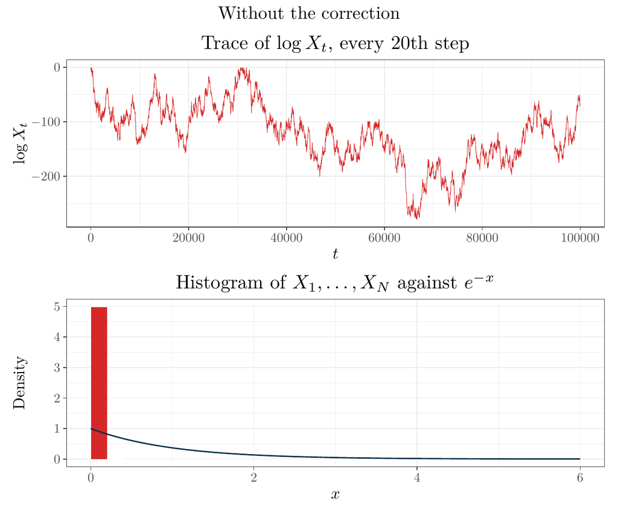

```r
set.seed(536)
chain_figure <- function(u, colr, title, png_file) {
  # every 20th step of the trace, so the figure stays small
  keep <- seq(1, length(u), by = 20)
  p_trace <- ggplot(data.frame(t = keep - 1, u = u[keep]), aes(t, u)) +
    geom_line(color = colr, linewidth = 0.4) +
    scale_x_continuous(breaks = int_breaks, labels = tex_num) +
    scale_y_continuous(labels = tex_num) +
    labs(title = r"(Trace of $\log X_t$, every 20th step)",
         x = "$t$", y = r"($\log X_t$)") +
    tex_theme

  xs <- seq(0, 6, length.out = 300)
  p_hist <- ggplot(data.frame(x = exp(u[-1])), aes(x)) +
    geom_histogram(aes(y = after_stat(density)), binwidth = 0.2,
                   boundary = 0, fill = colr, color = "white",
                   linewidth = 0.1) +
    geom_line(data = data.frame(x = xs, y = exp(-xs)), aes(x, y),
              color = pal[["dark"]], linewidth = 1.2) +
    coord_cartesian(xlim = c(0, 6)) +
    scale_x_continuous(labels = tex_num) +
    scale_y_continuous(labels = tex_num) +
    labs(title = r"(Histogram of $X_1, \ldots, X_N$ against $e^{-x}$)",
         x = "$x$", y = "Density") +
    tex_theme

  p <- p_trace / p_hist +
    plot_annotation(title = title, theme = theme(
      plot.title = element_text(size = 19, hjust = 0.5)))
  knitr::include_graphics(tikz_png(p, png_file, width = 9, height = 7.5))
}

chain_figure(no_corr$chain, pal[["red"]], "Without the correction",
             "figures/lab10/exp-without.png")
```

```r
set.seed(536)
with_corr <- mh_log_scale(N, s = 1, x0 = 1, log_pi = log_pi_exp,
                          correct = TRUE)
x_with_corr <- exp(with_corr$chain[-1])
# the ESS of X_1, ..., X_N
ess_with <- unname(coda::effectiveSize(x_with_corr))
# the Monte Carlo standard error of the mean
mcse_with <- sd(x_with_corr) / sqrt(ess_with)

print(sprintf("Acceptance rate: %.4f", with_corr$accept_rate))
print(sprintf("Share below 0.2: %.4f", mean(x_with_corr < 0.2)))
print(sprintf("Mean:            %.4f", mean(x_with_corr)))
print(sprintf("Median:          %.4f", median(x_with_corr)))
print(sprintf("ESS:             %.0f", ess_with))
print(sprintf("Standard error:  %.4f", mcse_with))
```

```
[1] "Acceptance rate: 0.7278"
[1] "Share below 0.2: 0.1836"
[1] "Mean:            0.9936"
[1] "Median:          0.6915"
[1] "ESS:             12407"
[1] "Standard error:  0.0089"
```

Run the figure chunk. It draws the same two panels for the chain with the correction.

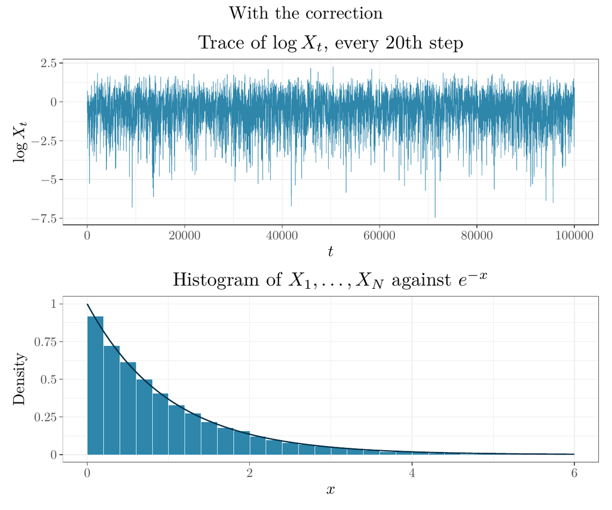

```r
set.seed(536)
chain_figure(with_corr$chain, pal[["blue"]], "With the correction",
             "figures/lab10/exp-with.png")
```

```r
set.seed(536)
N <- 1e5
B <- 1000
post_mean <- 219 / 50.5
# the log of the Gamma posterior, up to a constant
log_pi_gamma <- function(x) 218 * log(x) - 50.5 * x

gamma_runs <- lapply(c(FALSE, TRUE), function(correct) {
  set.seed(536)
  mh_log_scale(N, s = 0.3, x0 = 5, log_pi = log_pi_gamma,
               correct = correct)
})

gamma_row <- function(run) {
  # the draws after the burn-in, on the original scale
  lambda <- exp(run$chain[-(1:(B + 1))])
  ess <- unname(coda::effectiveSize(lambda))
  # the Monte Carlo standard error of the mean
  mcse <- sd(lambda) / sqrt(ess)
  # the distance from the posterior mean, in standard errors
  z <- (mean(lambda) - post_mean) / mcse
  data.frame(accept = run$accept_rate, mean = mean(lambda),
             ess = round(ess), mcse = mcse, z = z)
}
tab_gamma <- do.call(rbind, lapply(gamma_runs, gamma_row))
rownames(tab_gamma) <- c("without", "with")
print(round(tab_gamma, 4))
```

```
        accept   mean   ess   mcse       z
without 0.2692 4.3208 17857 0.0022 -7.2967
with    0.2690 4.3383 17935 0.0022  0.7517
```

**Report.**

1. From task 1: the acceptance rate, the share of draws below 0.2 against $1 - e^{-0.2} = 0.181$ under $\Exp(1)$, and the mean and the median against 1 and $\log 2 = 0.693$, with the figure.
2. From task 2: the same four numbers, the ESS, and the Monte Carlo standard error of the mean, with the figure.
3. One sentence on why the acceptance rate of task 1 is no evidence that the chain works.
4. The table of task 3, and one sentence that quotes how far each mean is from 4.3366 in standard errors.
5. Your answer to task 4 with its steps, and how it accounts for the means of task 3 and the draws of task 1.

**Task 1.** Without the correction the acceptance rate is 0.9992. The share of draws below 0.2 is 0.9977, against 0.181 under $\Exp(1)$. The mean is 0.001956 and the median is $2.5 \times 10^{-53}$, against 1 and $\log 2 = 0.693$. The trace of $\log X_t$ wanders far below 0. The smallest draw is about $10^{-122}$, and no draw after step 31,809 is above 0.2. On a long enough run $X_t$ gets so small that `exp()` returns 0, and a chain on $x$ would stay at 0 for good. That is why the chain runs on $u$.

The acceptance rate of 0.9992 is no evidence that the chain works. When $x$ and $y$ are both near 0, the ratio $\pi(y)/\pi(x) = e^{-(y - x)}$ is close to 1, so the chain accepts almost every proposal while it drifts away from where $\Exp(1)$ puts its mass. The acceptance rate counts moves. It does not check where the moves take the chain.

**Task 2.** With the correction the acceptance rate is 0.7278. The share of draws below 0.2 is 0.1836, against 0.181. The mean is 0.9936 with Monte Carlo standard error 0.0089, so it is 0.73 standard errors below 1. The median is 0.6915, against $\log 2 = 0.6931$. The ESS is 12,407 of 100,000. The histogram follows $e^{-x}$. The two chains used the same $Z$ and the same uniforms at every step, so the factor $y/x$ accounts for the whole difference between the two figures.

**Task 3.** Without the correction the mean is 4.3208 with standard error 0.0022, which is 7.30 standard errors below 4.3366. With the correction it is 4.3383 with standard error 0.0022, which is 0.75 standard errors above 4.3366. The two chains accept at the rates 0.2692 and 0.2690, so here too the acceptance rate does not tell them apart.

**Task 4.** Without the correction the chain accepts with probability $\min\bigl(1, \pi(y)/\pi(x)\bigr)$. On the log scale its proposal $v = u + Z$ has the density $\phi(v; u, s^2)$, and $\phi(v; u, s^2) = \phi(u; v, s^2)$. So for $v \ne u$ the chain in $u$ moves with the transition density

$$K_u(u, v) = \phi(v; u, s^2)\,\min\left(1, \frac{\pi(e^{v})}{\pi(e^{u})}\right).$$

This is Metropolis for the function $\pi(e^{u})$: a symmetric proposal, and the ratio of that function at $v$ and at $u$. Detailed balance holds for it:

$$\begin{aligned}
\pi(e^{u})\,K_u(u, v) &= \phi(v; u, s^2)\,\min\bigl(\pi(e^{u}), \pi(e^{v})\bigr) \\
&= \phi(u; v, s^2)\,\min\bigl(\pi(e^{v}), \pi(e^{u})\bigr) \\
&= \pi(e^{v})\,K_u(v, u).
\end{aligned}$$

So if $\int_{-\infty}^{\infty}\pi(e^{u})\,du < \infty$, the chain $U_t = \log X_t$ has the stationary density

$$f_U(u) = c\,\pi(e^{u}), \qquad \frac1c = \int_{-\infty}^{\infty}\pi(e^{u})\,du.$$

Back on the original scale, $x = e^{u}$ and $u = \log x$, so $du/dx = 1/x$. The change of variables gives the stationary density of $X_t$:

$$\begin{aligned}
f_X(x) &= f_U(\log x)\,\frac{du}{dx} \\
&= c\,\pi(e^{\log x})\,\frac1x \\
&= \boxed{c\,\frac{\pi(x)}{x}}.
\end{aligned}$$

The chain without the correction keeps $\pi(x)/x$ stationary. The missing factor $y/x$ in the acceptance probability is a missing factor $x$ in the stationary density.

For the Gamma posterior, $\pi(\lambda \mid \mathbf{x}) \propto \lambda^{218}e^{-50.5\lambda}$, so

$$\frac{\pi(\lambda \mid \mathbf{x})}{\lambda} \propto \frac{\lambda^{218}e^{-50.5\lambda}}{\lambda} = \lambda^{217}e^{-50.5\lambda}.$$

This is the kernel of $\Gam(218, 50.5)$, with mean $218/50.5 = 4.3168$. That is $1/50.5 = 0.0198$ below the posterior mean $219/50.5$. In task 3 the chain without the correction had mean 4.3208, which is 1.81 standard errors above 4.3168.

For $\Exp(1)$, $\pi(x)/x = e^{-x}/x$. For $0 < x \le 1$ we have $e^{-x} \ge e^{-1}$, so

$$\int_0^\infty \frac{e^{-x}}{x}\,dx \ge \int_0^1 \frac{e^{-x}}{x}\,dx \ge e^{-1}\int_0^1 \frac{dx}{x} = \infty.$$

So $e^{-x}/x$ cannot be normalized, and no $c$ exists. An irreducible chain with a stationary distribution has only one solution of the stationarity equation, up to a constant. So this chain has no stationary distribution. For every $\epsilon > 0$ the integral of $e^{-x}/x$ over $(0, \epsilon)$ is infinite and the integral over $(\epsilon, \infty)$ is finite, and the share of time the chain spends above $\epsilon$ tends to 0. In task 1, 0.9977 of the draws were below 0.2.

# Problem 2: The Independence Sampler

The independence sampler proposes from one fixed density, wherever the chain is.

**NoteIndependence sampler**

Propose $Y \sim q$, the same density at every step. The weight $w(x) = \pi(x)/q(x)$ is the importance weight of week 4, and

$$\alpha(x, y) = \min\left(1, \frac{w(y)}{w(x)}\right).$$

- If $\pi(x)/q(x) \le M$ for all $x$, the chain converges geometrically from every start, at rate $1 - 1/M$.
- If $\pi(x)/q(x)$ is unbounded, the chain is not geometrically ergodic.

Our target is $\pi = \Normal(0, 1)$. The proposal is $q = \Normal(0, \sigma^2)$, with $\sigma = 1.2$ or $\sigma = 0.5$.

1. Complete `independence_sampler(N, q_sd, x0)` below, with `q_sd` for $\sigma$. It works with $\log w$, which the code chunk defines, and returns the chain $X_0, X_1, \ldots, X_N$ and the acceptance rate. Run it with $N = 10^5$ and $x_0 = 0$, once with $\sigma = 1.2$ and once with $\sigma = 0.5$. For each run, compute the acceptance rate, the longest stay at one state, the share of draws with $|X_t| > 2$, and the ESS. Under the target, $P(|X| > 2) = 2\Phi(-2) = 0.0455$, with $\Phi$ the $\Normal(0, 1)$ CDF.
2. On paper, find $\sup_x \pi(x)/q(x)$ for each $\sigma$. The supremum is the smallest $M$ with $\pi(x)/q(x) \le M$ for all $x$, or $\infty$ if there is none. Recall accept-reject from week 3? With target $\pi$ and proposal $q$, it needs $\pi(x) \le M q(x)$ for all $x$, and it accepts with probability $1/M$. Show that when $\pi/q \le M$, the independence sampler accepts with probability at least $1/M$ from every state: $1 - r_{\text{rej}}(x) \ge 1/M$ for all $x$. Then check it on your chain with $\sigma = 1.2$, in the last code chunk below. It computes the acceptance rate over all steps, and over the steps taken from states with $|X_t| < 0.1$.

```r
set.seed(536)
independence_sampler <- function(N, q_sd, x0) {
  # the log of the weight w(x) = pi(x) / q(x)
  log_w <- function(x) {
    dnorm(x, log = TRUE) - dnorm(x, 0, q_sd, log = TRUE)
  }
  x <- numeric(N + 1)
  x[1] <- x0
  accepted <- 0
  for (t in 1:N) {
    # the proposal, which ignores the current state
    y <- rnorm(1, 0, q_sd)
    # the log of w(y) / w(x)
    log_ratio <- log_w(y) - log_w(x[t])
    # accept or stay
    if (log(runif(1)) <= log_ratio) {
      x[t + 1] <- y
      accepted <- accepted + 1
    } else {
      x[t + 1] <- x[t]
    }
  }
  list(chain = x, accept_rate = accepted / N)
}

N <- 1e5
q_sds <- c(1.2, 0.5)
runs <- lapply(q_sds, function(q_sd) {
  set.seed(536)
  independence_sampler(N, q_sd, x0 = 0)
})
wide <- runs[[1]]
narrow <- runs[[2]]

ind_row <- function(run) {
  # X_1, ..., X_N
  x <- run$chain[-1]
  # the longest stay at one state
  longest <- max(rle(x)$lengths)
  # the share of draws with |X_t| > 2
  tail_share <- mean(abs(x) > 2)
  ess <- unname(coda::effectiveSize(x))
  data.frame(accept = run$accept_rate, longest = longest,
             tail_share = tail_share, ess = round(ess))
}
tab_ind <- cbind(q_sd = q_sds, do.call(rbind, lapply(runs, ind_row)))
print(round(tab_ind, 4))
```

```
  q_sd accept longest tail_share   ess
1  1.2 0.8830       6     0.0455 88196
2  0.5 0.6019     739     0.0263  1683
```

Run the figure chunk. It draws the 4000 steps around the longest stay of the chain with $\sigma = 0.5$, for both chains. The dashed lines are at $\pm 2$.

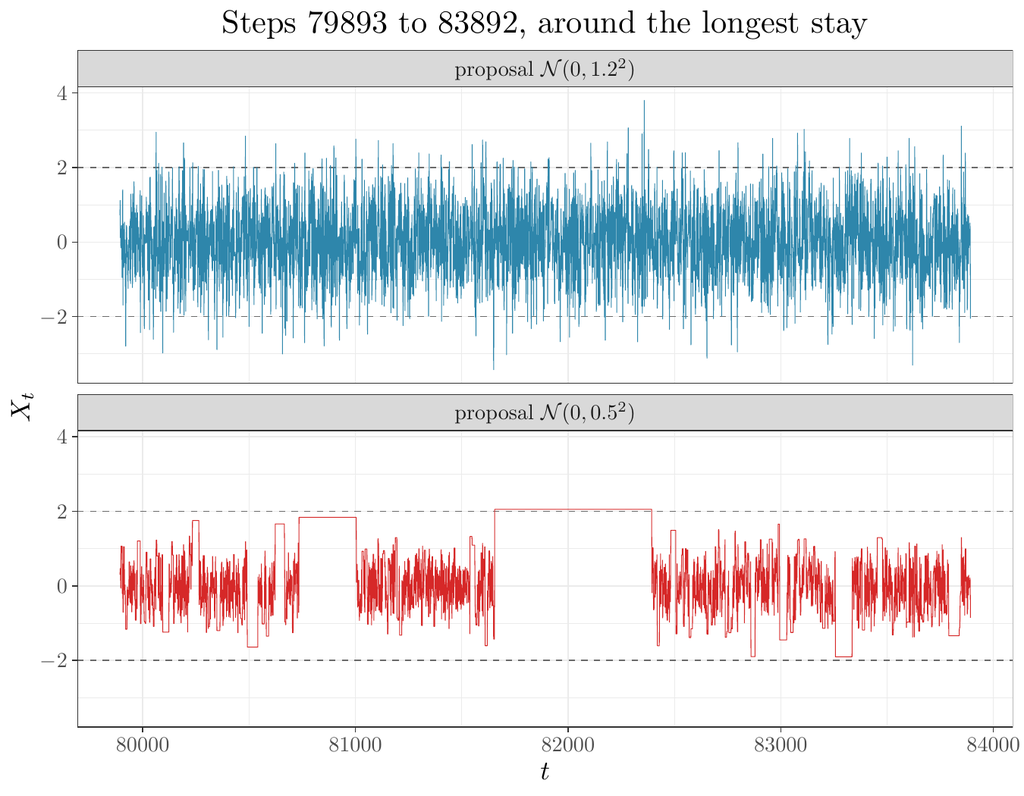

```r
set.seed(536)
# the 4000 steps around the longest stay of the chain with q_sd = 0.5
stays <- rle(narrow$chain)
stay_end <- cumsum(stays$lengths)[which.max(stays$lengths)]
first <- max(1, stay_end - 2500)
window <- first:min(N + 1, first + 3999)
q_labs <- c(r"(proposal $\mathcal{N}(0, 1.2^2)$)",
            r"(proposal $\mathcal{N}(0, 0.5^2)$)")
df_tr <- data.frame(t = rep(window - 1, 2),
                    x = c(wide$chain[window], narrow$chain[window]),
                    q = factor(rep(q_labs, each = length(window)),
                               levels = q_labs))

p <- ggplot(df_tr, aes(t, x, color = q)) +
  geom_hline(yintercept = c(-2, 2), linetype = "dashed",
             color = pal[["grey"]]) +
  geom_line(linewidth = 0.4) +
  facet_wrap(~ q, ncol = 1) +
  scale_color_manual(values = unname(pal[c("blue", "red")]),
                     guide = "none") +
  scale_x_continuous(breaks = int_breaks, labels = tex_num) +
  scale_y_continuous(labels = tex_num) +
  labs(title = sprintf("Steps %d to %d, around the longest stay",
                       min(window) - 1, max(window) - 1),
       x = "$t$", y = "$X_t$") +
  tex_theme

knitr::include_graphics(tikz_png(p, "figures/lab10/ind-traces.png",
                                 width = 9, height = 7))
```

```r
set.seed(536)
# sup of pi(x) / q(x) for q_sd = 1.2
M <- 1.2
# the steps of the chain with q_sd = 1.2 at which it moved
moved <- diff(wide$chain) != 0
# the steps taken from states with |X_t| < 0.1
near_0 <- abs(wide$chain[-(N + 1)]) < 0.1
acc_near_0 <- mean(moved[near_0])

print(sprintf("1/M:                          %.4f", 1 / M))
print(sprintf("Acceptance rate, all steps:   %.4f", wide$accept_rate))
print(sprintf("Acceptance rate, |X_t| < 0.1: %.4f", acc_near_0))
print(sprintf("Steps from |X_t| < 0.1:       %d", sum(near_0)))
```

```
[1] "1/M:                          0.8333"
[1] "Acceptance rate, all steps:   0.8830"
[1] "Acceptance rate, |X_t| < 0.1: 0.8326"
[1] "Steps from |X_t| < 0.1:       8029"
```

**Report.**

1. For each $\sigma$: the acceptance rate, the longest stay, the share of draws with $|X_t| > 2$ against 0.0455, and the ESS, with the figure.
2. $\sup_x \pi(x)/q(x)$ for each $\sigma$, with your steps.
3. Your proof that $1 - r_{\text{rej}}(x) \ge 1/M$, and the two acceptance rates of the check against $1/M = 0.833$.
4. One sentence on what the chain with $\sigma = 0.5$ does in the tails, and why.

**Task 1.** With $\sigma = 1.2$ the acceptance rate is 0.8830, and the longest stay at one state is 6 steps. The share of draws with $|X_t| > 2$ is 0.0455, against 0.0455 under the target, and the ESS is 88,196 of 100,000. With $\sigma = 0.5$ the acceptance rate is 0.6019, and the longest stay is 739 steps, at $x = 2.054$. The share of draws with $|X_t| > 2$ is 0.0263, below 0.0455, and the ESS is 1,683. In the figure, the chain with $\sigma = 1.2$ moves on most steps and is past $\pm 2$ at 171 of the 4,000 steps. The chain with $\sigma = 0.5$ sits at 2.054 for 739 steps.

**Task 2.** The density of $\Normal(0, \sigma^2)$ is $\phi(x; 0, \sigma^2) = \phi(x/\sigma; 0, 1)/\sigma$. So

$$\begin{aligned}
\frac{\pi(x)}{q(x)} &= \frac{\phi(x; 0, 1)}{\phi(x/\sigma; 0, 1)/\sigma} \\
&= \sigma\,\frac{e^{-x^2/2}}{e^{-x^2/(2\sigma^2)}} \\
&= \sigma\exp\left(-\frac{x^2}{2}\Bigl(1 - \frac{1}{\sigma^2}\Bigr)\right).
\end{aligned}$$

For $\sigma = 1.2$ we have $1 - 1/\sigma^2 = 0.3056 > 0$, so the exponent is at most 0, with equality at $x = 0$. Thus

$$\sup_x \frac{\pi(x)}{q(x)} = 1.2 = M, \quad \text{attained at } x = 0.$$

For $\sigma = 0.5$ we have $1 - 1/\sigma^2 = -3$, so

$$\frac{\pi(x)}{q(x)} = 0.5\,e^{1.5x^2} \to \infty \quad \text{as } |x| \to \infty,$$

and the ratio is unbounded. No $M$ exists.

Now suppose $w(x) = \pi(x)/q(x) \le M$ for all $x$. For any $x$ and $y$, since $w(x) \le M$ and $w(y) \le M$,

$$\alpha(x, y) = \min\left(1, \frac{w(y)}{w(x)}\right) \ge \min\left(1, \frac{w(y)}{M}\right) = \frac{w(y)}{M}.$$

The probability of accepting from $x$ is then

$$\begin{aligned}
1 - r_{\text{rej}}(x) &= \int q(y)\,\alpha(x, y)\,dy \\
&\ge \int q(y)\,\frac{w(y)}{M}\,dy \\
&= \frac1M\int \pi(y)\,dy \\
&= \boxed{\frac1M},
\end{aligned}$$

since $q(y)\,w(y) = \pi(y)$ and $\pi$ is a density. At $x = 0$ the bound is attained: $w(0) = M$, so $\alpha(0, y) = w(y)/M$ for every $y$, and $1 - r_{\text{rej}}(0) = 1/M$. Accept-reject with the same $q$ accepts a proposal $y$ with probability $\pi(y)/\bigl(Mq(y)\bigr) = w(y)/M$, the lower bound on $\alpha(x, y)$ above, so it accepts with probability $1/M = 0.833$ overall. From every state, the independence sampler accepts at least as often as accept-reject.

On the run with $\sigma = 1.2$, the acceptance rate over all steps is 0.8830, above $1/M = 0.8333$. Over the 8,029 steps taken from states with $|X_t| < 0.1$ it is 0.8326, with standard error 0.0042, which is 0.17 standard errors below $1/M$. Near 0 the weight is close to its largest value $M$, so the bound is nearly attained there. Away from 0 the weight is smaller, and the chain accepts more often.

With $\sigma = 0.5$ no $M$ exists. Accept-reject cannot use this proposal, and the independence sampler has no floor under its acceptance probability: from $x = 2$ it accepts with probability 0.0048.

The chain with $\sigma = 0.5$ reaches the tails rarely, and stays there long when it does. Its proposal puts probability $2\Phi(-4) = 6.3 \times 10^{-5}$ beyond $|y| = 2$, and in this run the chain reached 10 states beyond $\pm 2$. At such a state the weight $w(x) = 0.5\,e^{1.5x^2}$ is large, and almost every proposal lands near 0, where the weight is small. So $\alpha(x, Y) = w(Y)/w(x)$ is tiny: from $x = 2.054$ the chain accepts with probability 0.0035, and it stays 289 steps there on average. The largest $|X_t|$ in the run is 2.150. The target puts 0.0316 of its mass beyond it, and the chain never went there.

# Summary and Reflection

## Takeaways

1. **Without the correction the chain samples another density.** On the Gamma posterior its mean was 4.3208, 7.30 standard errors below 4.3366 and close to $218/50.5 = 4.3168$. On $\Exp(1)$ it has no stationary distribution at all.
2. **A high acceptance rate is no evidence that a chain works.** Without the correction the chain on $\Exp(1)$ accepted 0.9992 of its proposals and put 0.9977 of its draws below 0.2.
3. **A bound on $\pi/q$ puts a floor under the acceptance probability.** With $M = 1.2$ the independence sampler accepts with probability at least $1/M = 0.833$ from every state. With unbounded weights the chain stayed 739 steps at one state.

## Self-Assessment Questions

1. Show that $q(x \mid y)/q(y \mid x) = y/x$ for the proposal $Y = x\,e^{Z}$, starting from the density of $\log Y$.
2. Find the correction $q(x \mid y)/q(y \mid x)$ for the proposal $\operatorname{logit} Y = \operatorname{logit} x + Z$ on $(0, 1)$, with $Z \sim \Normal(0, s^2)$ and $\operatorname{logit} x = \log\bigl(x/(1 - x)\bigr)$.
3. Explain why leaving out the correction did more damage on $\Exp(1)$ than on the Gamma posterior.
4. Explain why the share of draws with $|X_t| > 2$ from the chain with $\sigma = 0.5$ changes a lot from one run to the next.